## Pollution, Death, Hospitals…

# The Final Project!

## By: Amy Recio, Joseph Staples, Jonathan Pollard

1. We used various data sets from California and New York centering around Health, Healthcare, and Environmentmental measures.
2. We created Extract, Transform, and Load files in R for necessary datas set to prepare the data to be uploaded to the Oracle SQL database to be accessed later in Tableau workbooks and Shiny modules.

```r
source("../01 Data/Leading_Cause_Of_Death_ETL.R", echo = TRUE)
```

```
##
## > require(tidyr)
```

```
##
## > require(dplyr)
```

```
##
## > require(ggplot2)
```

```
##
## > setwd("~/DataVisualizations/csv")
##
## > file_path <- "Leading_Causes_of_Death_by_Zip_Code__1999-2013.csv"
##
## > df <- read.csv(file_path, stringsAsFactors = FALSE)
##
## > names(df) <- gsub("\\.+", "_", names(df))
##
## > str(df)
## 'data.frame':    320152 obs. of  5 variables:
##  $ Year           : int  1999 1999 1999 1999 1999 1999 1999 1999 1999 1999 ...
##  $ ZIP_Code       : int  90001 90001 90001 90002 90002 90003 90003 90004 90004 90005 ...
##  $ Causes_of_Death: chr  "SUI" "HYP" "NEP" "HYP" ...
##  $ Count          : int  0 0 0 0 0 0 0 0 0 0 ...
##  $ Location       : chr  "(33.973092999999999, -118.247896)" "(33.973092999999999, -118.247896)" "(33.973092999999999, -118.247896)" "(33.949689999999997, -118.246213)" ...
##
## > measures <- c("Year", "Zip_Code", "Count")
##
## > for (n in names(df)) {
## +     df[n] <- data.frame(lapply(df[n], gsub, pattern = "[^ -~]",
## +         replacement = ""))
## + }
##
## > dimensions <- setdiff(names(df), measures)
##
## > if (length(measures) > 1 || !is.na(dimensions)) {
## +     for (d in dimensions) {
## +         df[d] <- data.frame(lapply(df[d], gsub, pattern = "[\"']", ..." ... [TRUNCATED]
##
## > library(lubridate)
##
## > write.csv(df, paste(gsub(".csv", "", file_path), ".reformatted.csv",
## +     sep = ""), row.names = FALSE, na = "")
##
## > tableName <- gsub(" +", "_", gsub("[^A-z, 0-9, ]",
## +     "", gsub(".csv", "", file_path)))
##
## > sql <- paste("CREATE TABLE", tableName, "(\n-- Change table_name to the table name you want.\n")
##
```

[output cut: 8 more lines]

```
## +         if (m != tail(measures, n = 1))
## +             sql <- paste(sq .... [TRUNCATED]
##
## > sql <- paste(sql, ");")
##
## > cat(sql)
## CREATE TABLE Leading_Causes_of_Death_by_Zip_Code__19992013 (
## -- Change table_name to the table name you want.
##  ZIP_Code varchar2(4000),
##  Causes_of_Death varchar2(4000),
##  Location varchar2(4000),
##  Year number(38,4),
##  Zip_Code number(38,4),
##  Count number(38,4)
##  );
```

```r
source("../01 Data/Zipcode_file_ETL.R", echo = TRUE)
```

```
##
## > require(tidyr)
##
## > require(dplyr)
##
## > require(ggplot2)
##
## > setwd("~/DataVisualizations/csv")
##
## > file_path <- "free-zipcode-database.csv"
##
## > df <- read.csv(file_path, stringsAsFactors = FALSE)
##
## > names(df) <- gsub("\\.+", "_", names(df))
##
## > str(df)
## 'data.frame':    81831 obs. of  20 variables:
##  $ RecordNumber       : int  1 2 3 4 5 6 7 8 9 10 ...
##  $ Zipcode            : int  704 704 704 704 704 704 704 704 705 705 ...
##  $ ZipCodeType        : chr  "STANDARD" "STANDARD" "STANDARD" "STANDARD" ...
##  $ City               : chr  "PARC PARQUE" "PASEO COSTA DEL SUR" "SECT LANAUSSE" "URB EUGENE RICE" ...
##  $ State              : chr  "PR" "PR" "PR" "PR" ...
##  $ LocationType       : chr  "NOT ACCEPTABLE" "NOT ACCEPTABLE" "NOT ACCEPTABLE" "NOT ACCEPTABLE" ...
##  $ Lat                : num  18 18 18 18 18 ...
##  $ Long               : num  -66.2 -66.2 -66.2 -66.2 -66.2 ...
##  $ Xaxis              : num  0.38 0.38 0.38 0.38 0.38 0.38 0.38 0.38 0.38 0.38 ...
##  $ Yaxis              : num  -0.87 -0.87 -0.87 -0.87 -0.87 -0.87 -0.87 -0.87 -0.86 -0.86 ...
##  $ Zaxis              : num  0.3 0.3 0.3 0.3 0.3 0.3 0.3 0.3 0.31 0.31 ...
##  $ WorldRegion        : chr  NA NA NA NA ...
##  $ Country            : chr  "US" "US" "US" "US" ...
##  $ LocationText       : chr  "Parc Parque, PR" "Paseo Costa Del Sur, PR" "Sect Lanausse, PR" "Urb Eugene Rice, PR" ...
##  $ Location           : chr  "NA-US-PR-PARC PARQUE" "NA-US-PR-PASEO COSTA DEL SUR" "NA-US-PR-SECT LANAUSSE" "NA-US-PR-URB EUGENE RICE" ...
##  $ Decommisioned      : logi  FALSE FALSE FALSE FALSE FALSE FALSE ...
##  $ TaxReturnsFiled    : int  NA NA NA NA NA NA NA NA NA NA ...
##  $ EstimatedPopulation: int  NA NA NA NA NA NA NA NA NA NA ...
##  $ TotalWages         : int  NA NA NA NA NA NA NA NA NA NA ...
##  $ Notes              : chr  "" "" "" "" ...
##
## > measures <- c("RecordNumber", "Zipcode")
##
```

[output cut: 43 more lines]

```
##  Xaxis varchar2(4000),
##  Yaxis varchar2(4000),
##  Zaxis varchar2(4000),
##  WorldRegion varchar2(4000),
##  Country varchar2(4000),
##  LocationText varchar2(4000),
##  Location varchar2(4000),
##  Decommisioned varchar2(4000),
##  TaxReturnsFiled varchar2(4000),
##  EstimatedPopulation varchar2(4000),
##  TotalWages varchar2(4000),
##  Notes varchar2(4000),
##  RecordNumber number(38,4),
##  Zipcode number(38,4)
##  );
```

```r
source("../01 Data/Hospital_Profitability_ETL.R", echo = TRUE)
```

```
##
## > library(stats)
##
## > require(tidyr)
##
## > require(dplyr)
##
## > require(ggplot2)
##
## > setwd("~/DataVisualizations/csv")
##
## > file_path <- "Hospital_Profitability__2009-2013.csv"
##
## > df <- read.csv(file_path, stringsAsFactors = FALSE)
##
## > names(df) <- gsub("\\.+", "_", names(df))
##
## > str(df)
## 'data.frame':    28626 obs. of  10 variables:
##  $ Year                           : int  2009 2009 2009 2009 2009 2009 2009 2009 2009 2009 ...
##  $ Facility_Number                : int  106010735 106010735 106010735 106010735 106010735 106010735 106010735 106010735 106010735 106010735 ...
##  $ Facility_Name                  : chr  "ALAMEDA HOSPITAL" "ALAMEDA HOSPITAL" "ALAMEDA HOSPITAL" "ALAMEDA HOSPITAL" ...
##  $ Begin_Date                     : chr  "7/1/2008" "7/1/2008" "7/1/2008" "7/1/2008" ...
##  $ End_Date                       : chr  "6/30/2009" "6/30/2009" "6/30/2009" "6/30/2009" ...
##  $ County_Name                    : chr  "Alameda" "Alameda" "Alameda" "Alameda" ...
##  $ Type_of_Control                : chr  "District" "District" "District" "District" ...
##  $ Income_Statement_Item          : chr  "GR_PT_REV" "DED_REV_PLUS_DSH" "TOT_CAP_REV" "NET_REV_LESS_DSH" ...
##  $ Income_Statement_Amount        : num  2.83e+08 2.20e+08 0.00 6.31e+07 1.92e+05 ...
##  $ Amount_per_Adjusted_Patient_Day: int  5220 4056 0 1164 4 1270 -103 116 0 0 ...
##
## > measures <- c("Year", "FacilityNumber", "IncAmt",
## +     "AdjAmtPerDay")
##
## > for (n in names(df)) {
## +     df[n] <- data.frame(lapply(df[n], gsub, pattern = "[^ -~]",
## +         replacement = ""))
## + }
##
## > dimensions <- setdiff(names(df), measures)
##
```

[output cut: 29 more lines]

```
## -- Change table_name to the table name you want.
##  Facility_Number varchar2(4000),
##  Facility_Name varchar2(4000),
##  Begin_Date varchar2(4000),
##  End_Date varchar2(4000),
##  County_Name varchar2(4000),
##  Type_of_Control varchar2(4000),
##  Income_Statement_Item varchar2(4000),
##  Income_Statement_Amount varchar2(4000),
##  Amount_per_Adjusted_Patient_Day varchar2(4000),
##  Year number(38,4),
##  FacilityNumber number(38,4),
##  IncAmt number(38,4),
##  AdjAmtPerDay number(38,4)
##  );
```

3. We created a ui.R file and server.R file to launch the Shiny app.

```r
source("../04 Shiny/ui.R", echo = TRUE)
```

```
##
## > require(shiny)
```

```
##
## > require(shinydashboard)
```

```
##
## > require(leaflet)
```

[output not shown]

[output cut: 26 more lines]

[output not shown]

```r
source("../04 Shiny/server.R", echo = TRUE)
```

```
##
## > require("jsonlite")
```

```
##
## > require("RCurl")
```

```
##
## > require(ggplot2)
##
## > require(dplyr)
##
## > require(shiny)
##
## > require(shinydashboard)
##
## > require(leaflet)
##
## > require(DT)
```

```
##
## > shinyServer(function(input, output) {
## +     KPI_Low_Max_value <- reactive({
## +         input$KPI1
## +     })
## +     KPI_Medium_Max_value <- reactive({
## + .... [TRUNCATED]
```

4. We used Tableau to create the following graphs and data visualizations on our topics.

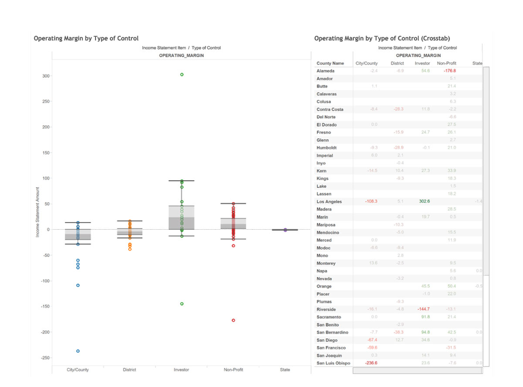

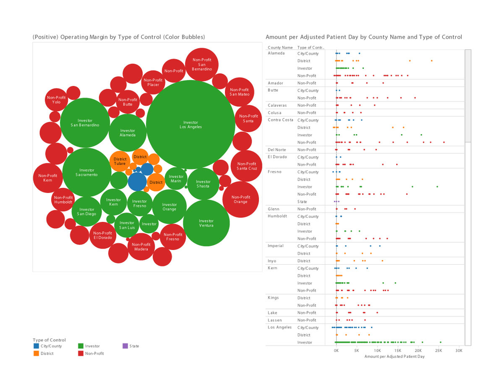

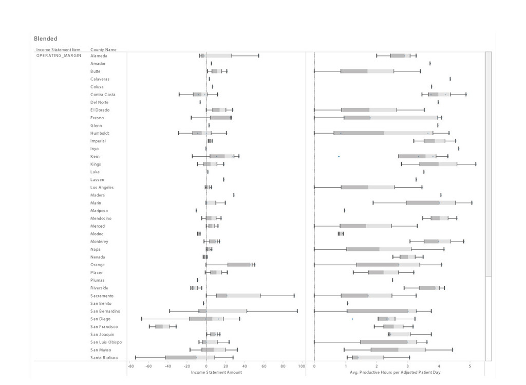

# Air Quality & Significance

**Every day, chemicals are being released into the air. At times, these are beneficial to our environment, but other times, they can be harmful. We explore the importance of maintaining a good Nitrogen Dioxide emission amount, because too much can affect the ozone levels and in turn affect the health of society. Additionally, we explored several states and how the air quality has changed over the years.**

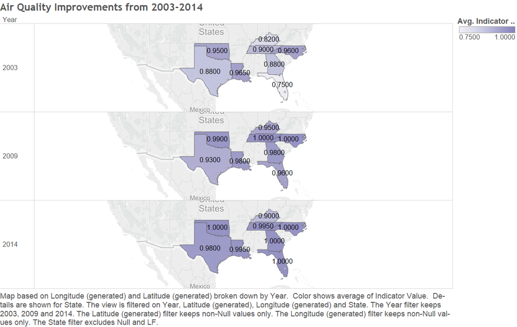

It’s very interesting to compare the air quality over time amongst these selected states. From 2003 to 2014, each state’s air quality has improved. However, there are a few states that received better air quality in 2009 than they had in 2014. Still, overall, it’s a nice thing to note that the air quality in these states has only gotten better since a decade ago.

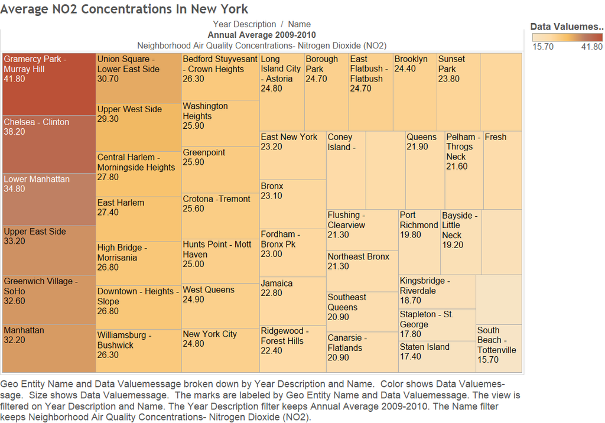

In this graph, the darker boxes indicate the neighborhoods of New York City which are exposed to higher concentrations of Nitrogen Dioxide. It’s interesting to note how different the Nitrogen Dioxide Levels are throughout the city of New York. Nitrogen Dioxide has potential to be very harmful when its concentration is too high. NO2 is emitted through road traffic as well as other fossil fuels, and takes a part in forming pollutants like O3. NO2 is hazardous as it can decrease lung function, lead to illnesses such as bronchitis, and most importantly, it can trigger asthma attacks amongst people with asthma and even children with or without it. Additionally, it has been shown that NO2 exposure enhances allergens’ effects.

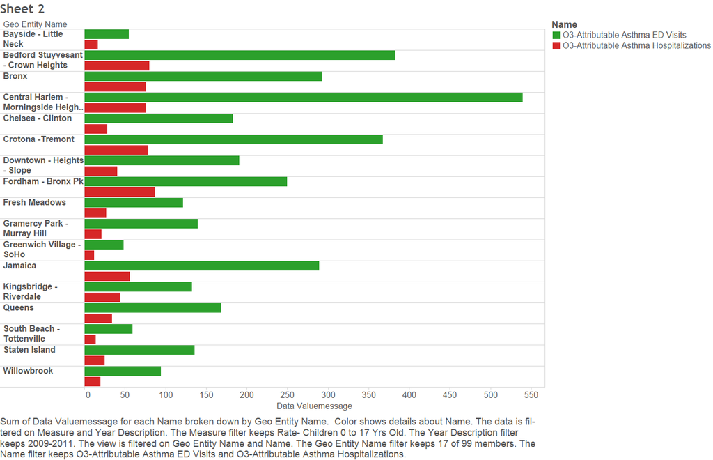

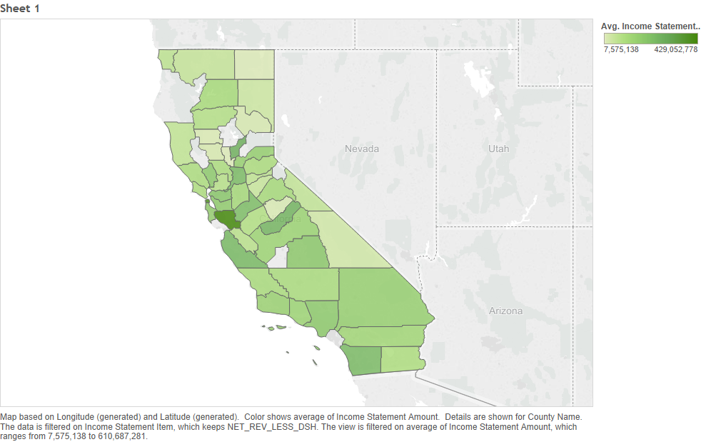

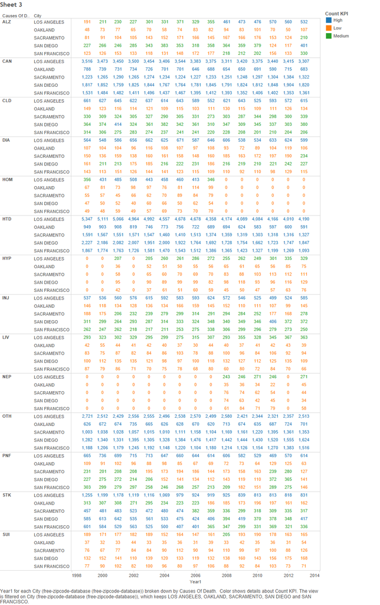

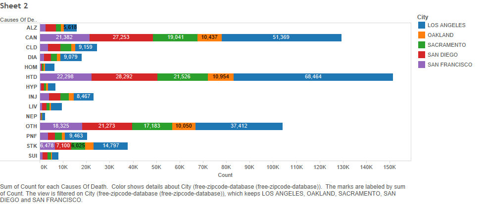

5. We deployed the finished shiny app(s) onto the shinyapp.io server after recreating or drawing inspiration from some of the more interesting Tableau graphs and outputs:

URL: https://addison.shinyapps.io/Health